# Win Big Results

2024-06-29

# **Experiment 1a**

**Contingencies**

##### Low Value Options

- Fixed: 20 (Door 3)
- Risky: 0 or 40 (Door 4)

##### High Value Options

- Fixed: 60 (Door 1)
- Risky: 40 or 80 (Door 2)

##### Trials

- Six blocks of 80 trials.
- *Decision Trials*: (fixed low vs risky low) & (fixed high vs risky high) - 24 per block (12 low, 12 high)
- *Single door trials*: one door to click - 40 per block
- *Catch trials*: high vs low - 16 per block

##### EX 80-20

- Block 1: 80% extreme values (0 low, 80 high)
- Block 2: 50% extreme values.
- Block 3: 20% extreme values (0 low, 80 high)
- Block 4-6: Block 2: 50% extreme values.

##### EX 20-80

- Block 1: 20% extreme values (0 low, 80 high)
- Block 2: 50% extreme values.
- Block 3: 80% extreme values (0 low, 80 high)
- Block 4-6: 50% extreme values.

##### EX 50 (control)

- All blocks: 50% extreme values.

## Participant Information

**Pre-catch exclusion**

N = 192

| group | gender | n | age_mean | age_sd | age_median | age_IQR |
| --- | --- | --- | --- | --- | --- | --- |
| EX 80-20 | F | 38 | 19.447 | 3.644 | 18 | 1.75 |
| EX 80-20 | M | 28 | 19.607 | 2.347 | 19 | 2.00 |
| EX 20-80 | F | 39 | 20.179 | 4.667 | 19 | 2.00 |
| EX 20-80 | M | 24 | 19.375 | 1.952 | 19 | 2.00 |
| EX 50 | F | 38 | 19.132 | 1.711 | 18 | 1.75 |
| EX 50 | M | 25 | 20.320 | 3.198 | 19 | 3.00 |

**Post-catch exclusion**

N = 184

| group | gender | n | age_mean | age_sd | age_median | age_IQR |
| --- | --- | --- | --- | --- | --- | --- |
| EX 80-20 | F | 36 | 19.278 | 3.669 | 18 | 1 |
| EX 80-20 | M | 27 | 19.519 | 2.343 | 19 | 2 |
| EX 20-80 | F | 39 | 20.179 | 4.667 | 19 | 2 |
| EX 20-80 | M | 23 | 19.435 | 1.973 | 19 | 2 |
| EX 50 | F | 37 | 19.162 | 1.724 | 18 | 2 |
| EX 50 | M | 22 | 20.318 | 3.272 | 19 | 3 |

#### Condition totals:

| group | n | age_mean | age_sd | age_median | age_IQR |
| --- | --- | --- | --- | --- | --- |
| EX 80-20 | 63 | 19.381 | 3.149 | 19 | 1.5 |
| EX 20-80 | 62 | 19.903 | 3.887 | 19 | 2.0 |
| EX 50 | 59 | 19.593 | 2.457 | 19 | 2.0 |

- Total number of catch trial exclusions = 8.
- Catch trial exclusions were based on block 6 performance.

## Catch Trials

**Plot - Block means with 95% CIs**

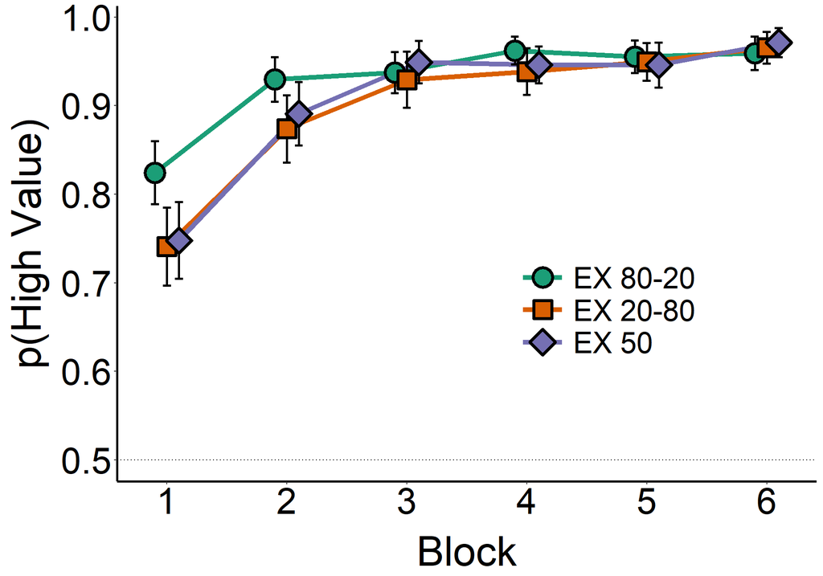

## Risk Preference Trials

**Plot - Block means with 95% CIs**

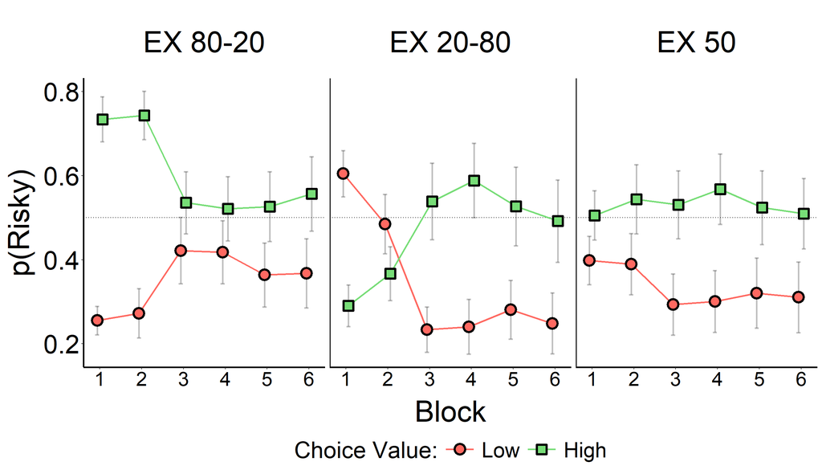

**Plot - Histogram of Responses (Group ~ Block)**

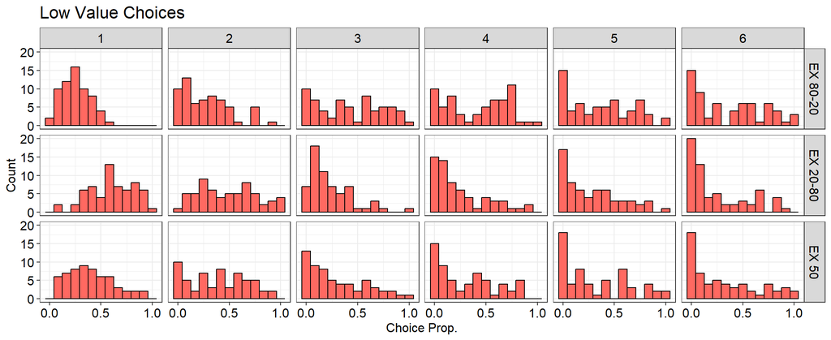

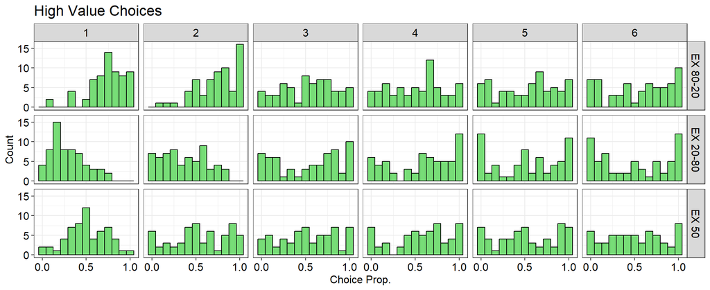

**Main Effects**

#### ANOVA Table

- Note: All blocks (1 - 6) were included.

|  | Model | df | AIC | BIC | logLik | Test | L.Ratio | p.value | BF_10 |
| --- | --- | --- | --- | --- | --- | --- | --- | --- | --- |
| base_mod | 1 | 5 | 379.964 | 408.463 | -184.982 |  | NA | NA | NA |
| grp_mod | 2 | 7 | 379.313 | 419.212 | -182.656 | 1 vs 2 | 4.651 | 0.098 | 5.000000e-03 |
| value_mod | 3 | 8 | 310.099 | 355.698 | -147.050 | 2 vs 3 | 71.213 | 0.000 | 6.191607e+13 |
| blk_mod | 4 | 13 | 301.854 | 375.952 | -137.927 | 3 vs 4 | 18.246 | 0.003 | 0.000000e+00 |
| grp_val | 5 | 15 | 298.138 | 383.635 | -134.069 | 4 vs 5 | 7.716 | 0.021 | 2.100000e-02 |
| grp_blk | 6 | 25 | 314.133 | 456.629 | -132.066 | 5 vs 6 | 4.005 | 0.947 | 0.000000e+00 |
| val_blk | 7 | 30 | 298.493 | 469.489 | -119.247 | 6 vs 7 | 25.639 | 0.000 | 2.000000e-03 |
| grp_val_blk | 8 | 40 | -27.388 | 200.606 | 53.694 | 7 vs 8 | 345.882 | 0.000 | 2.439043e+58 |

**Main Effect of Group:**

$\chi^2(2) = 4.65, p = 0.098, BF_{10} < .01$

**Main Effect of Choice Value (i.e., Extreme Outcome effect):**

$\chi^2(1) = 71.21, p < .001, BF_{10} > 150$

**Main Effect of Block:**

$\chi^2(5) = 18.25, p = 0.003, BF_{10} < .01$

**Interaction: Group $\times$ Value:**

$\chi^2(2) = 7.72, p = 0.021, BF_{10} = 0.021$

**Interaction: Group $\times$ Block:**

$\chi^2(10) = 4.01, p = 0.947, BF_{10} < .01$

**Interaction: Value $\times$ Block:**

$\chi^2(5) = 25.64, p < .001, BF_{10} < .01$

**Interaction: Group $\times$ Value $\times$ Block:**

$\chi^2(10) = 345.88, p < .001, BF_{10} > 150$

# **Experiment 1b**

**Contingencies**

##### Low Value Options

- Fixed: 20 (Door 3)
- Risky: 0 or 40 (Door 4)

##### High Value Options

- Fixed: 60 (Door 1)
- Risky: 40 or 80 (Door 2)

##### Trials

- Six blocks of 80 trials.
- Decision Trials: (fixed low vs risky low) & (fixed high vs risky high) - 24 per block (12 low, 12 high)
- Single door trials: one door to click - 40 per block
- Catch trials: high vs low - 16 per block

##### BEST 80-20

- Block 1: 80% chance of best outcome on risky options.
- Block 2: 50% of best outcome on risky options.
- Block 3: 20% chance of best outcome on risky options.
- Block 4-6: 50% of best outcome on risky options.

##### BEST 20-80

- Block 1: 20% chance of best outcome on risky options.
- Block 2: 50% of best outcome on risky options.
- Block 3: 80% chance of best outcome on risky options.
- Block 4-6: 50% of best outcome on risky options.

##### BEST 50 (control)

- All blocks: 50% of best outcome on risky options.

## Participant Information

**Pre-catch exclusion**

N = 190

| group | gender | n | age_mean | age_sd | age_median | age_IQR |
| --- | --- | --- | --- | --- | --- | --- |
| BEST 80-20 | F | 48 | 19.500 | 3.156 | 18.0 | 1 |
| BEST 80-20 | M | 13 | 19.231 | 1.787 | 19.0 | 1 |
| BEST 20-80 | F | 38 | 18.842 | 1.636 | 18.0 | 1 |
| BEST 20-80 | M | 25 | 19.840 | 1.748 | 19.0 | 2 |
| BEST 50 | F | 50 | 19.220 | 3.699 | 18.5 | 1 |
| BEST 50 | M | 16 | 19.375 | 1.544 | 19.0 | 2 |

**Post-catch exclusion**

N = 184

| group | gender | n | age_mean | age_sd | age_median | age_IQR |
| --- | --- | --- | --- | --- | --- | --- |
| BEST 80-20 | F | 48 | 19.500 | 3.156 | 18 | 1 |
| BEST 80-20 | M | 13 | 19.231 | 1.787 | 19 | 1 |
| BEST 20-80 | F | 37 | 18.865 | 1.653 | 18 | 1 |
| BEST 20-80 | M | 25 | 19.840 | 1.748 | 19 | 2 |
| BEST 50 | F | 46 | 19.326 | 3.842 | 19 | 1 |
| BEST 50 | M | 15 | 19.467 | 1.552 | 19 | 2 |

#### Condition totals:

| group | n | age_mean | age_sd | age_median | age_IQR |
| --- | --- | --- | --- | --- | --- |
| BEST 80-20 | 61 | 19.443 | 2.907 | 18 | 1 |
| BEST 20-80 | 62 | 19.258 | 1.746 | 19 | 2 |
| BEST 50 | 61 | 19.361 | 3.411 | 19 | 1 |

- Total number of catch trial exclusions = 6.
- Catch trial exclusions were based on block 6 performance.

## Catch Trials

**Plot - Block means with 95% CIs**

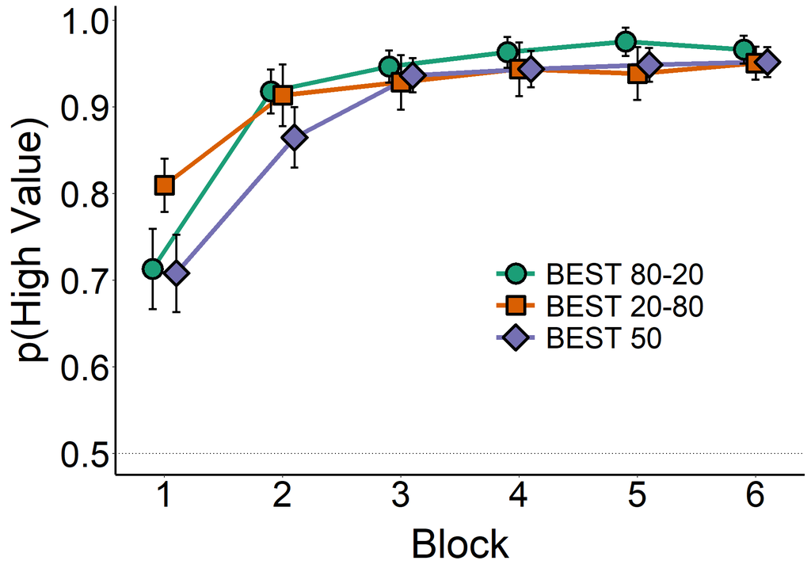

## Risk Preference Trials

**Plot - Block means with 95% CIs**

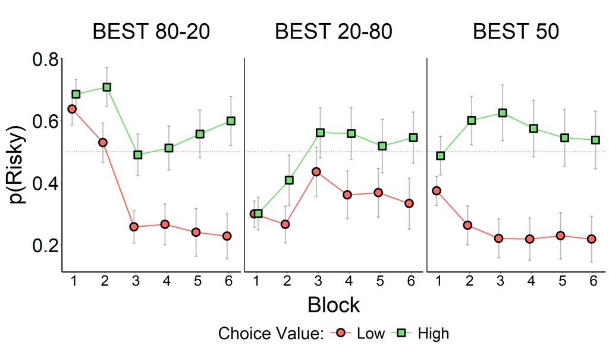

**Plot - Histogram of Responses (Group ~ Block)**

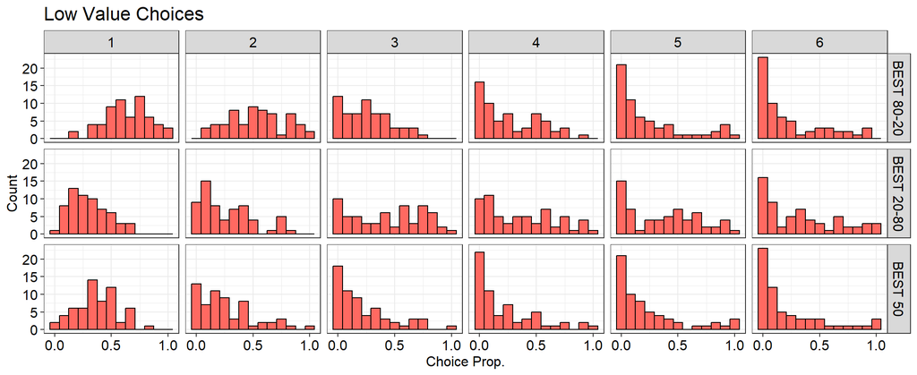

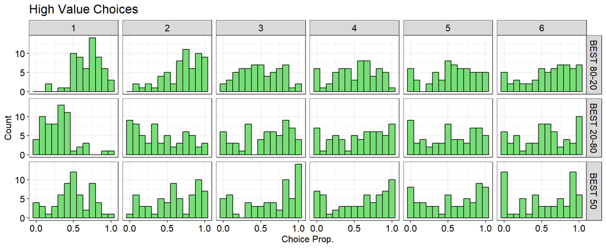

**Main Effects**

#### ANOVA Table

- Note: All blocks (1 - 6) were included.

|  | Model | df | AIC | BIC | logLik | Test | L.Ratio | p.value | BF_10 |
| --- | --- | --- | --- | --- | --- | --- | --- | --- | --- |
| base_mod | 1 | 5 | 285.236 | 313.736 | -137.618 |  | NA | NA | NA |
| grp_mod | 2 | 7 | 284.218 | 324.117 | -135.109 | 1 vs 2 | 5.018 | 0.081 | 6.000000e-03 |
| value_mod | 3 | 8 | 176.101 | 221.700 | -80.051 | 2 vs 3 | 110.117 | 0.000 | 1.736017e+22 |
| blk_mod | 4 | 13 | 161.451 | 235.549 | -67.725 | 3 vs 4 | 24.650 | 0.000 | 1.000000e-03 |
| grp_val | 5 | 15 | 150.615 | 236.112 | -60.307 | 4 vs 5 | 14.836 | 0.001 | 7.540000e-01 |
| grp_blk | 6 | 25 | -134.354 | 8.142 | 92.177 | 5 vs 6 | 304.969 | 0.000 | 3.185372e+49 |
| val_blk | 7 | 30 | -218.048 | -47.053 | 139.024 | 6 vs 7 | 93.694 | 0.000 | 9.667346e+11 |
| grp_val_blk | 8 | 40 | -219.210 | 8.784 | 149.605 | 7 vs 8 | 21.162 | 0.020 | 0.000000e+00 |

**Main Effect of Group:**

$\chi^2(2) = 5.02, p = 0.081, BF_{10} < .01$

**Main Effect of Choice Value (i.e., Extreme Outcome effect):**

$\chi^2(1) = 110.12, p < .001, BF_{10} > 150$

**Main Effect of Block:**

$\chi^2(5) = 24.65, p < .001, BF_{10} < .01$

**Interaction: Group $\times$ Value:**

$\chi^2(2) = 14.84, p < .001, BF_{10} = 0.754$

**Interaction: Group $\times$ Block:**

$\chi^2(10) = 304.97, p < .001, BF_{10} > 150$

**Interaction: Value $\times$ Block:**

$\chi^2(5) = 93.69, p < .001, BF_{10} > 150$

**Interaction: Group $\times$ Value $\times$ Block:**

$\chi^2(10) = 21.16, p = 0.02, BF_{10} < .01$

# **R Citations**

R version 4.4.0 (2024-04-24 ucrt)

- nlme (3.1.164) (Pinheiro et al., 2023)
- patchwork (1.2.0) (Pedersen, 2022)
- RColorBrewer (1.1.3) (Neuwirth, 2022)
- rcompanion (2.4.35) (Mangiafico, 2023)
- tidyverse (2.0.0) (Wickham et al., 2019)
- WRS2 (1.1.6) (Mair & Wilcox, 2020)

# **References**

Mair, P., & Wilcox, R. (2020). Robust Statistical Methods in R Using the WRS2 Package. *Behavior Research Methods*, *52*, 464–488.

Mangiafico, S. S. (2023). *rcompanion: Functions to support extension education program evaluation*. Rutgers Cooperative Extension. https://CRAN.R-project.org/package=rcompanion/

Neuwirth, E. (2022). *RColorBrewer: ColorBrewer palettes*. https://CRAN.R-project.org/package=RColorBrewer

Pedersen, T. L. (2022). *Patchwork: The composer of plots*. https://CRAN.R-project.org/package=patchwork

Pinheiro, J., Bates, D., & R Core Team. (2023). *nlme: Linear and nonlinear mixed effects models*. https://CRAN.R-project.org/package=nlme

R Core Team. (2023). *R: A language and environment for statistical computing*. R Foundation for Statistical Computing. https://www.R-project.org/

Wickham, H., Averick, M., Bryan, J., Chang, W., McGowan, L. D., François, R., Grolemund, G., Hayes, A., Henry, L., Hester, J., Kuhn, M., Pedersen, T. L., Miller, E., Bache, S. M., Müller, K., Ooms, J., Robinson, D., Seidel, D. P., Spinu, V., … Yutani, H. (2019). Welcome to the tidyverse. *Journal of Open Source Software*, *4*(43), 1686. https://doi.org/10.21105/joss.01686